| title: “24133064_Nguyễn Thị Kiều Trang_BaiTap_R” |
| --- |
| output: html_document |
| date: “2026-05-04” |

# Câu 1 - Vector creation (5 điểm)

## 1. Tạo vector từ -8 đến 9, bước 0.3

```r
x1 <- seq(from = -8, to = 9, by = 0.3)
x1
```

```
##  [1] -8.0 -7.7 -7.4 -7.1 -6.8 -6.5 -6.2 -5.9 -5.6 -5.3 -5.0 -4.7 -4.4 -4.1 -3.8
## [16] -3.5 -3.2 -2.9 -2.6 -2.3 -2.0 -1.7 -1.4 -1.1 -0.8 -0.5 -0.2  0.1  0.4  0.7
## [31]  1.0  1.3  1.6  1.9  2.2  2.5  2.8  3.1  3.4  3.7  4.0  4.3  4.6  4.9  5.2
## [46]  5.5  5.8  6.1  6.4  6.7  7.0  7.3  7.6  7.9  8.2  8.5  8.8
```

## 2. Ghi đè lại vector theo thứ tự ngược lại

```r
x1 <- rev(x1)
x1
```

```
##  [1]  8.8  8.5  8.2  7.9  7.6  7.3  7.0  6.7  6.4  6.1  5.8  5.5  5.2  4.9  4.6
## [16]  4.3  4.0  3.7  3.4  3.1  2.8  2.5  2.2  1.9  1.6  1.3  1.0  0.7  0.4  0.1
## [31] -0.2 -0.5 -0.8 -1.1 -1.4 -1.7 -2.0 -2.3 -2.6 -2.9 -3.2 -3.5 -3.8 -4.1 -4.4
## [46] -4.7 -5.0 -5.3 -5.6 -5.9 -6.2 -6.5 -6.8 -7.1 -7.4 -7.7 -8.0
```

## 3. Lặp vector và sắp xếp giảm dần

### Tạo vector ban đầu

```r
x3 <- c(-1, 3, -5, 7, -9)
```

### Lặp lại vector 2 lần, mỗi phần tử lặp 10 lần

```r
x3 <- rep(x3, times = 2, each = 10)
x3
```

```
##   [1] -1 -1 -1 -1 -1 -1 -1 -1 -1 -1  3  3  3  3  3  3  3  3  3  3 -5 -5 -5 -5 -5
##  [26] -5 -5 -5 -5 -5  7  7  7  7  7  7  7  7  7  7 -9 -9 -9 -9 -9 -9 -9 -9 -9 -9
##  [51] -1 -1 -1 -1 -1 -1 -1 -1 -1 -1  3  3  3  3  3  3  3  3  3  3 -5 -5 -5 -5 -5
##  [76] -5 -5 -5 -5 -5  7  7  7  7  7  7  7  7  7  7 -9 -9 -9 -9 -9 -9 -9 -9 -9 -9
```

### Sắp xếp giảm dần

```r
x_decrease <- sort(x3, decreasing = TRUE)
x_decrease
```

```
##   [1]  7  7  7  7  7  7  7  7  7  7  7  7  7  7  7  7  7  7  7  7  3  3  3  3  3
##  [26]  3  3  3  3  3  3  3  3  3  3  3  3  3  3  3 -1 -1 -1 -1 -1 -1 -1 -1 -1 -1
##  [51] -1 -1 -1 -1 -1 -1 -1 -1 -1 -1 -5 -5 -5 -5 -5 -5 -5 -5 -5 -5 -5 -5 -5 -5 -5
##  [76] -5 -5 -5 -5 -5 -9 -9 -9 -9 -9 -9 -9 -9 -9 -9 -9 -9 -9 -9 -9 -9 -9 -9 -9 -9
```

## 4. Tạo một vector theo thứ tự gồm: dãy số 1 đến 6;giá trị 3.5 lặp bốn lần; số -5; một dãy 9 giá trị bắt đầu từ 100 và kết thúc tại chiều dài của vector gốc ở ý trước.

```r
a <- 1:6
b <- rep(3.5, times=4)
c <- -5
base_vector <- c(a,b,c)
base_vector
```

```
##  [1]  1.0  2.0  3.0  4.0  5.0  6.0  3.5  3.5  3.5  3.5 -5.0
```

```r
seq(from=100, to = length(base_vector), length.out = 9)
```

```
## [1] 100.000  88.875  77.750  66.625  55.500  44.375  33.250  22.125  11.000
```

# Câu 2 - Vector indexing (6 điểm)

## 5. Tạo vector gồm: 5 phần tử cách đều từ 2 đến 8; vector c(1, -4.3, 13, -3.2) được lặp lại hai lần; và giá trị 1/7 + 5.

```r
a <- seq(from=2, to=8, length.out= 5)
b <- c(1,-4.3, 13, -3.2)
c <- 1/7+5
vector <- c(a,rep(b,2),c)
vector
```

```
##  [1]  2.000000  3.500000  5.000000  6.500000  8.000000  1.000000 -4.300000
##  [8] 13.000000 -3.200000  1.000000 -4.300000 13.000000 -3.200000  5.142857
```

## 6. Trích phần tử đầu và cuối của vector vừa tạo, lưu vào một biến mới.

```r
x6 <- c(vector[1], vector[length(vector)])
x6
```

```
## [1] 2.000000 5.142857
```

## 7. Tạo một biến mới lưu vector sau khi bỏ phần tử đầu và cuối.

```r
x7 <- vector[-c(1,length(vector))]
x7
```

```
##  [1]  3.5  5.0  6.5  8.0  1.0 -4.3 13.0 -3.2  1.0 -4.3 13.0 -3.2
```

## 8. Dùng hai vector ở hai ý trên để tạo lại vector ban đầu.

```r
x8 <- c(x6[1], x7, x6[2])
x8
```

```
##  [1]  2.000000  3.500000  5.000000  6.500000  8.000000  1.000000 -4.300000
##  [8] 13.000000 -3.200000  1.000000 -4.300000 13.000000 -3.200000  5.142857
```

## 9. Ghi đè vector ban đầu bằng phiên bản đã sắp xếp.

```r
x9 <- sort(x8, decreasing = TRUE)
x9
```

```
##  [1] 13.000000 13.000000  8.000000  6.500000  5.142857  5.000000  3.500000
##  [8]  2.000000  1.000000  1.000000 -3.200000 -3.200000 -4.300000 -4.300000
```

## 10. Đảo ngược vector đã sắp xếp bằng toán tử :.

```r
x_rev <- x9[length(x9):1]
x_rev
```

```
##  [1] -4.300000 -4.300000 -3.200000 -3.200000  1.000000  1.000000  2.000000
##  [8]  3.500000  5.000000  5.142857  6.500000  8.000000 13.000000 13.000000
```

## 11. Tạo vector mới từ vector đã bỏ đầu/cuối bằng cách lặp phần tử thứ 3 ba lần, phần tử thứ 4 bốn lần và phần tử cuối hai lần.

```r
vector_new <- c(rep(x7[3],3),
                rep(x7[4],4),
                rep(x7[length(x7)],2))
vector_new
```

```
## [1]  6.5  6.5  6.5  8.0  8.0  8.0  8.0 -3.2 -3.2
```

# Câu 3 - Vector operations (5 điểm)

## 12. Chuyển vector c(2, 0.5, 1, 2, 0.5, 1, 2, 0.5, 1) thành vector chỉ gồm các giá trị 1 bằng cách dùng một vector có chiều dài 3.

```r
x <- c(2, 0.5, 1, 2, 0.5, 1, 2, 0.5, 1)
x*rep(c(0.5,2,1),3)
```

```
## [1] 1 1 1 1 1 1 1 1 1
```

## 13. Cho vector c(45, 77, 20, 19, 101, 120, 212) mô tả nhiệt độ F. Chuyển sang độ C theo công thức C = 5/9 * (F - 32)

```r
F <- c(45, 77, 20, 19, 101, 120, 212)
5/9 * (F-32)
```

```
## [1]   7.222222  25.000000  -6.666667  -7.222222  38.333333  48.888889 100.000000
```

## 14. Dùng vector c(2, 4, 6), vector c(1, 2), hàm rep() và phép toán * để tạo vector c(2, 4, 6, 4, 8, 12).

```r
a <- rep(c(2,4,6), 2)
b <- rep(c(1,2), each =3)
x14 <-a*b
x14
```

```
## [1]  2  4  6  4  8 12
```

## 15. Ghi đè bốn phần tử ở giữa của vector ở ý trên bằng cách recycle hai giá trị -1 và -10 theo thứ tự.

```r
x14[2:5] <- rep(c(-1,-10), length.out=4)
x14
```

```
## [1]   2  -1 -10  -1 -10  12
```

## 16. Tạo và lưu ma trận 4 x 2 gồm các giá trị 4.3, 3.1, 8.2, 8.2, 3.2, 0.9, 1.6 và 6.5 theo thứ tự dòng.

```r
m <- matrix(c(4.3,3.1,
              8.2,8.2,
              3.2,0.9,
              1.6,6.5),
            nrow =4, ncol =2, byrow=TRUE
)
m
```

```
##      [,1] [,2]
## [1,]  4.3  3.1
## [2,]  8.2  8.2
## [3,]  3.2  0.9
## [4,]  1.6  6.5
```

## 17. Tạo biến mới từ ma trận trên bằng cách bỏ đi một dòng bất kỳ. Kiểm tra ma trận mới có kích thước 3 x 2.

```r
m_new <- m[-2, ]
m_new
```

```
##      [,1] [,2]
## [1,]  4.3  3.1
## [2,]  3.2  0.9
## [3,]  1.6  6.5
```

## 18. Ghi đè cột thứ hai của ma trận bằng giá trị của cột đó sau khi sắp xếp tăng dần.

```r
m[,2] <- sort(m[,2])
m
```

```
##      [,1] [,2]
## [1,]  4.3  0.9
## [2,]  8.2  3.1
## [3,]  3.2  6.5
## [4,]  1.6  8.2
```

## 19. Tạo biến mới bằng cách bỏ dòng 4 và cột 1. Đảm bảo kết quả là ma trận một cột, không phải vector.

```r
n <- m[-4,-1, drop=FALSE]
n
```

```
##      [,1]
## [1,]  0.9
## [2,]  3.1
## [3,]  6.5
```

## 20. Lưu bốn phần tử dưới cùng của ma trận thành ma trận 2x2

```r
m2 <- matrix(tail(as.vector(m),4), nrow=2, byrow=TRUE)
m2
```

```
##      [,1] [,2]
## [1,]  0.9  3.1
## [2,]  6.5  8.2
```

## 21. Ghi đè theo thứ tự các vị trí (4,2), (1,2), (4,1), (1,1) bằng một nửa các giá trị trên đường chéo chính của ma trận 2 x 2 ở ý trước.

```r
half_diag <- diag(m2)/2
m[4,2] <- half_diag[1]
m[1,2] <- half_diag[2]
m[4,1] <- half_diag[1]
m[1,1] <- half_diag[2]
m
```

```
##      [,1] [,2]
## [1,] 4.10 4.10
## [2,] 8.20 3.10
## [3,] 3.20 6.50
## [4,] 0.45 0.45
```

## 23. Cho A = [1; 2; 6] và B = [10; 3; 5]. Xác định những biểu thức nào tính được; nếu tính được, hãy tính giá trị: A * B; t(A) * B; t(B) * (A * t(A)); (A * t(A)) * t(B); [(B * t(B)) + (A * t(A)) - 100I3]^(-1), với I3 là ma trận đơn vị bậc 3. Ghi rõ biểu thức nào không hợp lệ và giải thích ngắn gọn.

```r
A <- matrix(c(1,2,6), ncol=1)
A
```

```
##      [,1]
## [1,]    1
## [2,]    2
## [3,]    6
```

```r
B <- matrix(c(10,3,5), ncol=1)
B
```

```
##      [,1]
## [1,]   10
## [2,]    3
## [3,]    5
```

### 1.A*B

```r
result1 <- A*B
result1
```

```
##      [,1]
## [1,]   10
## [2,]    6
## [3,]   30
```

### 2.t(A) * B

```r
result2 <- t(A)%*%B
result2
```

```
##      [,1]
## [1,]   46
```

### 3.t(B) * (A * t(A))

```r
result3 <- t(B)%*%(A%*%t(A))
result3
```

```
##      [,1] [,2] [,3]
## [1,]   46   92  276
```

### 4.(A * t(A)) * t(B)

#### result4 <- (A %*% t(A)) %*% t(B)

#### result4

#### Không tính được vì:

#### A %*% t(A) có kích thước 3x3

#### t(B) có kích thước 1x3

#### Số cột ma trận trái = 3

#### Số dòng ma trận phải = 1

#### 3 ≠ 1 nên không nhân được

### 5.[(B * t(B)) + (A * t(A)) - 100I3]^(-1)

```r
result5 <- solve((B %*% t(B)) + (A %*% t(A)) - 100*diag(3))
result5
```

```
##             [,1]         [,2]         [,3]
## [1,] 0.006462882  0.006695779  0.013915575
## [2,] 0.006695779 -0.007702572  0.004281902
## [3,] 0.013915575  0.004281902 -0.002695294
```

# Câu 6 - Array creation and indexing (6 điểm)

## 24. Tạo và lưu mảng 3 chiều gồm 6 layer, mỗi layer là ma trận 4 x 2, với các giá trị là dãy số cách đều từ 10 đến 1

```r
arr <- array(seq(from =10, to=1, length.out=48), dim=c(4,2,6))
arr
```

```
## , , 1
##
##           [,1]     [,2]
## [1,] 10.000000 9.234043
## [2,]  9.808511 9.042553
## [3,]  9.617021 8.851064
## [4,]  9.425532 8.659574
##
## , , 2
##
##          [,1]     [,2]
## [1,] 8.468085 7.702128
## [2,] 8.276596 7.510638
## [3,] 8.085106 7.319149
## [4,] 7.893617 7.127660
##
## , , 3
##
##          [,1]     [,2]
## [1,] 6.936170 6.170213
## [2,] 6.744681 5.978723
## [3,] 6.553191 5.787234
## [4,] 6.361702 5.595745
##
## , , 4
##
##          [,1]     [,2]
## [1,] 5.404255 4.638298
## [2,] 5.212766 4.446809
## [3,] 5.021277 4.255319
## [4,] 4.829787 4.063830
##
## , , 5
##
##          [,1]     [,2]
## [1,] 3.872340 3.106383
## [2,] 3.680851 2.914894
## [3,] 3.489362 2.723404
## [4,] 3.297872 2.531915
##
## , , 6
##
##          [,1]     [,2]
## [1,] 2.340426 1.574468
## [2,] 2.148936 1.382979
## [3,] 1.957447 1.191489
## [4,] 1.765957 1.000000
```

## 25. Tạo biến mới bằng cách lọc các phần tử ở dòng 1 và 4, cột 2, trên tất cả các layer của mảng.

```r
arr2 <- arr[c(1,4), 2, ]
arr2
```

```
##          [,1]     [,2]     [,3]     [,4]     [,5]     [,6]
## [1,] 9.234043 7.702128 6.170213 4.638298 3.106383 1.574468
## [2,] 8.659574 7.127660 5.595745 4.063830 2.531915 1.000000
```

```r
rep(arr2[2,],4)
```

```
##  [1] 8.659574 7.127660 5.595745 4.063830 2.531915 1.000000 8.659574 7.127660
##  [9] 5.595745 4.063830 2.531915 1.000000 8.659574 7.127660 5.595745 4.063830
## [17] 2.531915 1.000000 8.659574 7.127660 5.595745 4.063830 2.531915 1.000000
```

## 27. Tạo mảng mới bằng cách xóa layer thứ 6 của mảng ban đầu.

```r
arr3 <- arr[,,-6]
arr3
```

```
## , , 1
##
##           [,1]     [,2]
## [1,] 10.000000 9.234043
## [2,]  9.808511 9.042553
## [3,]  9.617021 8.851064
## [4,]  9.425532 8.659574
##
## , , 2
##
##          [,1]     [,2]
## [1,] 8.468085 7.702128
## [2,] 8.276596 7.510638
## [3,] 8.085106 7.319149
## [4,] 7.893617 7.127660
##
## , , 3
##
##          [,1]     [,2]
## [1,] 6.936170 6.170213
## [2,] 6.744681 5.978723
## [3,] 6.553191 5.787234
## [4,] 6.361702 5.595745
##
## , , 4
##
##          [,1]     [,2]
## [1,] 5.404255 4.638298
## [2,] 5.212766 4.446809
## [3,] 5.021277 4.255319
## [4,] 4.829787 4.063830
##
## , , 5
##
##          [,1]     [,2]
## [1,] 3.872340 3.106383
## [2,] 3.680851 2.914894
## [3,] 3.489362 2.723404
## [4,] 3.297872 2.531915
```

```r
arr[c(2,4),2, c(1,3,5)] <-1
arr
```

```
## , , 1
##
##           [,1]     [,2]
## [1,] 10.000000 9.234043
## [2,]  9.808511 1.000000
## [3,]  9.617021 8.851064
## [4,]  9.425532 1.000000
##
## , , 2
##
##          [,1]     [,2]
## [1,] 8.468085 7.702128
## [2,] 8.276596 7.510638
## [3,] 8.085106 7.319149
## [4,] 7.893617 7.127660
##
## , , 3
##
##          [,1]     [,2]
## [1,] 6.936170 6.170213
## [2,] 6.744681 1.000000
## [3,] 6.553191 5.787234
## [4,] 6.361702 1.000000
##
## , , 4
##
##          [,1]     [,2]
## [1,] 5.404255 4.638298
## [2,] 5.212766 4.446809
## [3,] 5.021277 4.255319
## [4,] 4.829787 4.063830
##
## , , 5
##
##          [,1]     [,2]
## [1,] 3.872340 3.106383
## [2,] 3.680851 1.000000
## [3,] 3.489362 2.723404
## [4,] 3.297872 1.000000
##
## , , 6
##
##          [,1]     [,2]
## [1,] 2.340426 1.574468
## [2,] 2.148936 1.382979
## [3,] 1.957447 1.191489
## [4,] 1.765957 1.000000
```

# Câu 7 - Logical vectors (5 điểm)

## Tạo vector c(6, 9, 7, 3, 6, 7, 9, 6, 3, 6, 6, 7, 1, 9, 1), sau đó thực hiện:

```r
vct <- c(6,9, 7, 3, 6, 7, 9, 6, 3, 6, 6, 7, 1, 9, 1)
vct
```

```
##  [1] 6 9 7 3 6 7 9 6 3 6 6 7 1 9 1
```

## 29. Xác định vị trí các phần tử bằng 6.

```r
which (vct==6)
```

```
## [1]  1  5  8 10 11
```

## 30. Xác định vị trí các phần tử lớn hơn hoặc bằng 6.

```r
which (vct>=6 )
```

```
##  [1]  1  2  3  5  6  7  8 10 11 12 14
```

## 31. Xác định vị trí các phần tử nhỏ hơn 6 + 2.

```r
which (vct < (6+2))
```

```
##  [1]  1  3  4  5  6  8  9 10 11 12 13 15
```

## 32. Xác định vị trí các phần tử khác 6.

```r
which (vct != 6)
```

```
##  [1]  2  3  4  6  7  9 12 13 14 15
```

```r
vct_new <- vct[-3]
arr <- array(vct_new, dim=c(2,2,3))
arr
```

```
## , , 1
##
##      [,1] [,2]
## [1,]    6    3
## [2,]    9    6
##
## , , 2
##
##      [,1] [,2]
## [1,]    7    6
## [2,]    9    3
##
## , , 3
##
##      [,1] [,2]
## [1,]    6    7
## [2,]    6    1
```

```r
before <- arr <= (6/2 + 4)
before
```

```
## , , 1
##
##       [,1] [,2]
## [1,]  TRUE TRUE
## [2,] FALSE TRUE
##
## , , 2
##
##       [,1] [,2]
## [1,]  TRUE TRUE
## [2,] FALSE TRUE
##
## , , 3
##
##      [,1] [,2]
## [1,] TRUE TRUE
## [2,] TRUE TRUE
```

```r
arr_incr <- arr+2
arr_incr
```

```
## , , 1
##
##      [,1] [,2]
## [1,]    8    5
## [2,]   11    8
##
## , , 2
##
##      [,1] [,2]
## [1,]    9    8
## [2,]   11    5
##
## , , 3
##
##      [,1] [,2]
## [1,]    8    9
## [2,]    8    3
```

```r
after <- arr_incr <= (6/2 +4)
after
```

```
## , , 1
##
##       [,1]  [,2]
## [1,] FALSE  TRUE
## [2,] FALSE FALSE
##
## , , 2
##
##       [,1]  [,2]
## [1,] FALSE FALSE
## [2,] FALSE  TRUE
##
## , , 3
##
##       [,1]  [,2]
## [1,] FALSE FALSE
## [2,] FALSE  TRUE
```

## 34. Dùng any(), all() và which() để kiểm tra và liệt kê vị trí TRUE trong các logical array.

```r
any(before)
```

```
## [1] TRUE
```

```r
all(before)
```

```
## [1] FALSE
```

```r
which(before)
```

```
##  [1]  1  3  4  5  7  8  9 10 11 12
```

# Câu 8 - Logical operations (5 điểm)

## 35. Tạo vector x = c(7, 1, 7, 10, 5, 9, 10, 3, 10, 8). Xác định các phần tử lớn hơn 5 hoặc bằng 2

```r
x <- c(7, 1, 7, 10, 5, 9, 10, 3, 10, 8)
x
```

```
##  [1]  7  1  7 10  5  9 10  3 10  8
```

```r
condition_x <- (x>5)|(x==2)
x[condition_x]
```

```
## [1]  7  7 10  9 10 10  8
```

## 36. Tạo vector y = c(8, 8, 4, 4, 5, 1, 5, 6, 6, 8). Xác định các phần tử bé hơn hoặc bằng 6 và khác 4.

```r
y <- c(8, 8, 4, 4, 5, 1, 5, 6, 6, 8)
y
```

```
##  [1] 8 8 4 4 5 1 5 6 6 8
```

```r
condition_y <- (y<=6)&(y!=4)
y[condition_y]
```

```
## [1] 5 1 5 6 6
```

## 37. Xác định những phần tử trong x hoặc y thỏa mãn đồng thời hai điều kiện ở hai ý trên.

```r
condition_all <- condition_x&condition_y
x[condition_all]
```

```
## [1]  9 10 10
```

```r
y[condition_all]
```

```
## [1] 1 5 6
```

## 38. Tạo z = x + y. Xác định các phần tử của z >= 14 nhưng khác 15; đồng thời xét vector y/x và trích các giá trị lớn hơn 4 hoặc nhỏ hơn hoặc bằng 2.

```r
z <- x+y
z
```

```
##  [1] 15  9 11 14 10 10 15  9 16 16
```

```r
condition_z <- (z >= 14) & (z != 15)
z[condition_z]
```

```
## [1] 14 16 16
```

```r
yx <- y / x
condition_yx <- (yx > 4) | (yx <= 2)
yx[condition_yx]
```

```
##  [1] 1.1428571 8.0000000 0.5714286 0.4000000 1.0000000 0.1111111 0.5000000
##  [8] 2.0000000 0.6000000 1.0000000
```

# Câu 9 - Logical indexing (6 điểm)

## 39. Tạo x = c(7, 5, 6, 1, 2, 10, 8, 3, 8, 2). Trích các phần tử >= 5 và gán cho y.

```r
x <- c(7, 5, 6, 1, 2, 10, 8, 3, 8, 2)
y <- x[x>=5]
y
```

```
## [1]  7  5  6 10  8  8
```

## 40. Liệt kê phần còn lại của x sau khi bỏ các phần tử >= 5

```r
x_remaining <- x[x<5]
x_remaining
```

```
## [1] 1 2 3 2
```

## 41. Dùng y để tạo ma trận z kích thước 2 x 3 theo thứ tự dòng.

```r
z <- matrix(
  y, nrow=2, ncol=3, byrow=TRUE
)
z
```

```
##      [,1] [,2] [,3]
## [1,]    7    5    6
## [2,]   10    8    8
```

## 42. Thay các phần tử có giá trị 8 trong z bằng bình phương của phần tử ở dòng 1, cột 2 của z.

```r
value_square <- z[1,2]^2
value_square
```

```
## [1] 25
```

```r
z[z==8]<-value_square
z
```

```
##      [,1] [,2] [,3]
## [1,]    7    5    6
## [2,]   10   25   25
```

## 43. Kiểm tra tất cả giá trị trong z có <= 25 và > 4 hay không

```r
all((z<=25)&(z>4))
```

```
## [1] TRUE
```

# PHẦN B. LAB 2 - STRING, FACTOR, LIST, DATA FRAME, CONTROL STRUCTURES VÀ FUNCTION

# Câu 1 - String (5 điểm)

## 44. Tạo và lưu chuỗi có dạng chính xác như sau, bao gồm xuống dòng và thụt dòng tương ứng:

### “The quick brown fox

### jumped over

### the lazy dogs”

```r
str1 <- "The quick brown fox
 jumped over
 the lazy dogs"
cat(str1)
```

```
## The quick brown fox
##  jumped over
##  the lazy dogs
```

## 45. Với num1 <- 4 và num2 <- 0.75, viết một dòng code xuất chuỗi: The result of multiplying 4 by 0.75 is 3. Kiểm tra kết quả 3 đúng bằng tích của hai biến.

```r
num1 <- 4
num2 <- 0.75
result <- num1 * num2
paste("The result of multiplying",
      num1,
      "by",
      num2,
      "is",
      result)
```

```
## [1] "The result of multiplying 4 by 0.75 is 3"
```

```r
result == (num1 * num2)
```

```
## [1] TRUE
```

## 46. Với home <- “data analysis/Labs/”, thay chuỗi data bằng AI.

```r
home <- "data analysis/Labs/"
sub("data", "AI", home)
```

```
## [1] "AI analysis/Labs/"
```

## 47. Với s <- “Learning programming with R is very interesting”, hãy: trích ký tự thứ 5 đến 10; chèn “easy and” trước “very interesting”; thay tất cả “ing” bằng “ed”.

```r
s <- "Learning programming with R is very interesting"
s
```

```
## [1] "Learning programming with R is very interesting"
```

```r
substring(s, 5, 10)
```

```
## [1] "ning p"
```

```r
sub("very interesting",
    "easy and very interesting",
    s)
```

```
## [1] "Learning programming with R is easy and very interesting"
```

```r
gsub("ing", "ed", s)
```

```
## [1] "Learned programmed with R is very interested"
```

# Câu 2 - Factor (7 điểm)

## a = c(2, 3, 6, 9, 12, 14, 19, 22, 28, 30, 33, 37, 42, 43, 45, 46, 49, 54, 57)

## b = c(1, 5, 8, 10, 11, 20, 21, 23, 25, 26, 32, 38, 39, 41, 44, 51)

## c = c(4, 7, 13, 15, 16, 17, 18, 24, 27, 29, 31, 34, 35, 36, 40, 47, 48, 50, 52, 53, 55, 56)

## 48. Tạo character vector sex nhận giá trị M/F và character vector class nhận giá trị A/B/C; kiểm tra các giá trị nằm đúng vị trí như mô tả.

```r
a <- c(2, 3, 6, 9, 12, 14, 19, 22, 28, 30, 33, 37, 42, 43, 45, 46, 49, 54, 57)
b <- c(1, 5, 8, 10, 11, 20, 21, 23, 25, 26, 32, 38, 39, 41, 44, 51)
c <- c(4, 7, 13, 15, 16, 17, 18, 24, 27, 29, 31, 34, 35, 36, 40, 47, 48, 50, 52, 53, 55, 56)
female <- c( 18, 33, 36, 49, 50, 5)
sex <- rep("M", 57)
sex[female] <- "F"
sex
```

```
##  [1] "M" "M" "M" "M" "F" "M" "M" "M" "M" "M" "M" "M" "M" "M" "M" "M" "M" "F" "M"
## [20] "M" "M" "M" "M" "M" "M" "M" "M" "M" "M" "M" "M" "M" "F" "M" "M" "F" "M" "M"
## [39] "M" "M" "M" "M" "M" "M" "M" "M" "M" "M" "F" "F" "M" "M" "M" "M" "M" "M" "M"
```

```r
class <- rep("", 57)
class[a] <- "A"
class[b] <- "B"
class[c] <- "C"
class
```

```
##  [1] "B" "A" "A" "C" "B" "A" "C" "B" "A" "B" "B" "A" "C" "A" "C" "C" "C" "C" "A"
## [20] "B" "B" "A" "B" "C" "B" "B" "C" "A" "C" "A" "C" "B" "A" "C" "C" "C" "A" "B"
## [39] "B" "C" "B" "A" "A" "B" "A" "A" "C" "C" "A" "C" "B" "C" "C" "A" "C" "C" "A"
```

```r
sex[female]
```

```
## [1] "F" "F" "F" "F" "F" "F"
```

```r
class[a]
```

```
##  [1] "A" "A" "A" "A" "A" "A" "A" "A" "A" "A" "A" "A" "A" "A" "A" "A" "A" "A" "A"
```

```r
class[b]
```

```
##  [1] "B" "B" "B" "B" "B" "B" "B" "B" "B" "B" "B" "B" "B" "B" "B" "B"
```

```r
class[c]
```

```
##  [1] "C" "C" "C" "C" "C" "C" "C" "C" "C" "C" "C" "C" "C" "C" "C" "C" "C" "C" "C"
## [20] "C" "C" "C"
```

## 49. Tạo hai factor vector từ sex và class. Giải thích ordered=TRUE có phù hợp không; nếu thêm ordered=TRUE, R sắp xếp levels như thế nào

```r
sex_factor <- factor(sex)
class_factor <- factor(class)
sex_factor
```

```
##  [1] M M M M F M M M M M M M M M M M M F M M M M M M M M M M M M M M F M M F M M
## [39] M M M M M M M M M M F F M M M M M M M
## Levels: F M
```

```r
class_factor
```

```
##  [1] B A A C B A C B A B B A C A C C C C A B B A B C B B C A C A C B A C C C A B
## [39] B C B A A B A A C C A C B C C A C C A
## Levels: A B C
```

### ordered = TRUE không phù hợp vì:

### giới tính và lớp học không có thứ tự tự nhiên

### Nếu thêm ordered = TRUE,

### R sẽ sắp xếp levels theo alphabet:

### A < B < C

### F < M

## 50. Trả về factor vector của lớp chỉ gồm sinh viên nam.

```r
class_factor[sex == "M"]
```

```
##  [1] B A A C A C B A B B A C A C C C A B B A B C B B C A C A C B C C A B B C B A
## [39] A B A A C C B C C A C C A
## Levels: A B C
```

## 51. Trả về factor vector của lớp A.

```r
class_factor[class == "A"]
```

```
##  [1] A A A A A A A A A A A A A A A A A A A
## Levels: A B C
```

## 52. Với vector month đã cho trong file lab, tạo biến quarter gồm Q1, Q2, Q3, Q4 tương ứng các tháng 1-3, 4-6, 7-9, 10-12.

```r
month <- 1:12
quarter <- factor(
  rep(c("Q1", "Q2", "Q3", "Q4"),
      each = 3)
)
quarter
```

```
##  [1] Q1 Q1 Q1 Q2 Q2 Q2 Q3 Q3 Q3 Q4 Q4 Q4
## Levels: Q1 Q2 Q3 Q4
```

## 53. Trích ra các sinh viên thuộc lớp A và sinh ở quí Q1.

```r
month <- rep(1:12, length.out = 57)
quarter <- factor(
  rep(c("Q1","Q2","Q3","Q4"), each = 3)
)
quarter_student <- quarter[month]
which((class == "A") & (quarter_student == "Q1"))
```

```
## [1]  2  3 14 37 49
```

# Câu 3 - List (7 điểm)

## 54. Tạo list gồm: dãy 20 giá trị từ -4 đến 4 cách đều nhau; logical matrix 3 x 3 theo cột từ c(F, T, T, T, F, T, T, F, F); vector gồm “don”, “quixote”; factor vector c(“LOW”,“MED”,“LOW”,“MED”,“MED”,“HIGH”).

```r
nums <- seq(from = -4,
            to = 4,
            length.out = 20)
logic_mat <- matrix(
  c(F, T, T,
    T, F, T,
    T, F, F),
  nrow = 3,
  byrow = FALSE
)
chars <- c("don", "quixote")
facs <- factor(
  c("LOW","MED","LOW","MED","MED","HIGH")
)
mylist <- list(
  nums,
  logic_mat,
  chars,
  facs
)
mylist
```

[output not shown]

## 55. Trích dòng 2 và 1 của cột 2 và 3 theo thứ tự từ logical matrix.

```r
mylist[[2]][c(2,1), c(2,3)]
```

[output not shown]

## 56. Dùng sub() để đổi “quixote” thành “Quixote” và “don” thành “Don”. Sau đó thêm chuỗi nhiều dòng: Windmills! ATTACK! / -Quixote/-.

```r
chars_new <- sub("don", "Don", chars)
chars_new <- sub("quixote",
                 "Quixote",
                 chars_new)
chars_new
```

```
## [1] "Don"     "Quixote"
```

```r
quote_text <- "Windmills!
ATTACK!
/-\\Don Quixote/-"
cat(quote_text)
```

```
## Windmills!
## ATTACK!
## /-\Don Quixote/-
```

## 57. Xuất các giá trị từ dãy -4 đến 4 lớn hơn 1.

```r
mylist[[1]][mylist[[1]] > 1]
```

```
## [1] 1.052632 1.473684 1.894737 2.315789 2.736842 3.157895 3.578947 4.000000
```

## 58. Dùng which() xác định vị trí của factor vector nhận giá trị MED.

```r
which(mylist[[4]] == "MED")
```

```
## [1] 2 4 5
```

## 59. Tạo list mới gồm facs, nums = c(3,2.1,3.3,4,1.5,4.9), và oldlist chứa ba thành phần đầu của list trước đó.

```r
nums2 <- c(3,2.1,3.3,4,1.5,4.9)
newlist <- list(
  facs = facs,
  nums = nums2,
  oldlist = mylist[1:3]
)
newlist
```

[output not shown]

## 60. Từ list mới, trích facs tương ứng với nums >= 3; thêm flags là logical vector chiều dài 6 từ việc lặp hai lần cột thứ 3 của logical matrix trong oldlist; dùng !flags để trích nums ứng với FALSE; ghi đè character string vector trong oldlist bằng “Don Quixote”.

```r
newlist$facs[newlist$nums >= 3]
```

```
## [1] LOW  LOW  MED  HIGH
## Levels: HIGH LOW MED
```

```r
flags <- rep(newlist$oldlist[[2]][,3], 2)
flags
```

[output not shown]

```r
newlist$nums[!flags]
```

[output not shown]

```r
newlist$oldlist[[3]] <- "Don Quixote"
newlist
```

[output not shown]

# Câu 4 - Data frame (8 điểm)

## Tạo data frame dframe như sau. person là character vector; sex là factor có levels F, M; funny là factor có levels Low, Med, High.

```r
person <- c("Stan",
            "Francine",
            "Steve",
            "Roger",
            "Hayley",
            "Klaus")

sex <- factor(
  c("M","F","M","M","F","M")
)
funny <- factor(
  c("High","Med","Low","High","Med","Med"),
  levels = c("Low","Med","High")
)
df <- data.frame(
  person,
  sex,
  funny
)
df
```

```
##     person sex funny
## 1     Stan   M  High
## 2 Francine   F   Med
## 3    Steve   M   Low
## 4    Roger   M  High
## 5   Hayley   F   Med
## 6    Klaus   M   Med
```

## 61. Thêm biến age: Stan và Francine 41 tuổi, Steve 15, Hayley 21, Klaus 60, Roger 1600 tuổi.

```r
df$age <- c(41,41,15,1600,21,60)
df
```

```
##     person sex funny  age
## 1     Stan   M  High   41
## 2 Francine   F   Med   41
## 3    Steve   M   Low   15
## 4    Roger   M  High 1600
## 5   Hayley   F   Med   21
## 6    Klaus   M   Med   60
```

## 62. Sắp xếp lại các cột theo thứ tự: person, age, sex, funny.

```r
df <- df[, c("person","age","sex","funny")]
df
```

```
##     person  age sex funny
## 1     Stan   41   M  High
## 2 Francine   41   F   Med
## 3    Steve   15   M   Low
## 4    Roger 1600   M  High
## 5   Hayley   21   F   Med
## 6    Klaus   60   M   Med
```

## 63. Thêm biến age.mon = age * 12.

```r
df$age.mon=df$age*12
df
```

```
##     person  age sex funny age.mon
## 1     Stan   41   M  High     492
## 2 Francine   41   F   Med     492
## 3    Steve   15   M   Low     180
## 4    Roger 1600   M  High   19200
## 5   Hayley   21   F   Med     252
## 6    Klaus   60   M   Med     720
```

## 64. Tạo anotherdframe theo bảng dưới đây, sau đó kết hợp với dframe để tạo newdframe.

```r
anotherframe <- data.frame(
  person = c("Peter",
             "Lois",
             "Meg",
             "Chris",
             "Stewie",
             "Brian"),

  age = c(42,40,17,14,1,7),
  sex = factor(c("M","F","F","M","M","M")),
  funny = factor(
    c("High","High","Low","Med","High","Med"),
    levels = c("Low","Med","High")
  ),
  age.mon = c(504,480,204,168,12,84)
)
anotherframe
```

```
##   person age sex funny age.mon
## 1  Peter  42   M  High     504
## 2   Lois  40   F  High     480
## 3    Meg  17   F   Low     204
## 4  Chris  14   M   Med     168
## 5 Stewie   1   M  High      12
## 6  Brian   7   M   Med      84
```

```r
newdf <- rbind(df, anotherframe)
newdf
```

```
##      person  age sex funny age.mon
## 1      Stan   41   M  High     492
## 2  Francine   41   F   Med     492
## 3     Steve   15   M   Low     180
## 4     Roger 1600   M  High   19200
## 5    Hayley   21   F   Med     252
## 6     Klaus   60   M   Med     720
## 7     Peter   42   M  High     504
## 8      Lois   40   F  High     480
## 9       Meg   17   F   Low     204
## 10    Chris   14   M   Med     168
## 11   Stewie    1   M  High      12
## 12    Brian    7   M   Med      84
```

## 65. Viết một dòng code trích person và age của những người là nữ và có funny là Med hoặc High.

```r
newdf[
  (newdf$sex == "F") &
    (newdf$funny %in% c("Med","High")),
  c("person","age")
]
```

```
##     person age
## 2 Francine  41
## 5   Hayley  21
## 8     Lois  40
```

## 66. Trích những người có tên bắt đầu bằng chữ S, gợi ý dùng substr().

```r
newdf[
  substr(newdf$person, 1, 1) == "S",
]
```

```
##    person age sex funny age.mon
## 1    Stan  41   M  High     492
## 3   Steve  15   M   Low     180
## 11 Stewie   1   M  High      12
```

# Câu 5 - if và switch (5 điểm)

```r
v1 <- c(2,1,1,3,2,1,0)
v2 <- c(3,8,2,2,0,0,0)
```

## 67. Dùng v1 và v2, viết một dòng code: nếu tổng hai phần tử tương ứng > 3 thì nhân chúng, ngược lại cộng chúng

```r
ifelse(v1+v2>3, v1*v2, v1+v2)
```

```
## [1] 6 8 3 6 2 1 0
```

## 68. Viết hàm tính tiền điện theo bảng bậc thang bên dưới, một phiên bản dùng if và một phiên bản dùng switch.

```r
tinh_tien_if <- function(kwh){
  if(kwh <= 50){
    price <- 1549
  } else if(kwh <= 100){
    price <- 1600
  } else if(kwh <= 200){
    price <- 1858
  } else if(kwh <= 300){
    price <- 2340
  } else if(kwh <= 400){
    price <- 2615
  } else {
    price <- 2701
  }
  kwh * price
}
tinh_tien_if(120)
```

```
## [1] 222960
```

```r
tinh_tien_switch <- function(kwh){
  price <- switch(
    TRUE,
    kwh <= 50  , 1549,
    kwh <= 100 , 1600,
    kwh <= 200 , 1858,
    kwh <= 300 , 2340,
    kwh <= 400 , 2615,
    2701
  )
  kwh * price
}
tinh_tien_switch(120)
```

```
## [1] 0
```

# Câu 6 - for (3 điểm)

## Cho đoạn code dùng hai vòng lặp for để tính ma trận tích ngoài giữa v1 = 1:3 và v2 = 4:7. Hãy viết lại bằng một vòng lặp for mà vẫn thu được kết quả tương tự.

```r
v1 <- 1:3
v2 <- 4:7
result <- matrix(
  0,
  nrow = length(v1),
  ncol = length(v2)
)
for(i in 1:length(v1)){
  result[i, ] <- v1[i] * v2
}
result
```

```
##      [,1] [,2] [,3] [,4]
## [1,]    4    5    6    7
## [2,]    8   10   12   14
## [3,]   12   15   18   21
```

# Câu 7 - while (3 điểm)

## Dùng while để tính n giai thừa. Biết 0! = 1 và i! = i * (i - 1)! với mọi i > 0, i thuộc N. Kiểm tra với n <- 10

```r
n <- 10
i <- 1
fact <- 1
while(i <= n){
  fact <- fact * i
  i <- i + 1
}
fact
```

```
## [1] 3628800
```

# Câu 8 - apply (4 điểm)

```r
a <- matrix(1:12, 3, 4)
b <- array(1:18, dim = c(3, 3, 2))
```

## 69. Thực thi các lệnh apply(a, 1, sum), apply(a, 2, sum), apply(b, 1, sum), apply(b, 2, sum), apply(b, 3, sum) và quan sát kết quả.

```r
apply(a, 1, sum)
```

```
## [1] 22 26 30
```

```r
apply(a, 2, sum)
```

```
## [1]  6 15 24 33
```

```r
apply(b, 1, sum)
```

```
## [1] 51 57 63
```

```r
apply(b, 2, sum)
```

```
## [1] 39 57 75
```

```r
apply(b, 3, sum)
```

```
## [1]  45 126
```

## 70. Dùng apply() để tính tổng các số lẻ ở mỗi dòng của ma trận a.

```r
apply(
  a,
  1,
  function(x){
    sum(x[x %% 2 == 1])
  }
)
```

```
## [1]  8 16 12
```

## 71. Dùng apply() để tính tích các số chẵn ở mỗi cột của ma trận a.

```r
apply(
  a,
  2,
  function(x){
    prod(x[x %% 2 == 0])
  }
)
```

```
## [1]   2  24   8 120
```

# Câu 9 - break, next và repeat (4 điểm)

## 72. Dùng vòng lặp for và next để tính tổng các số không chia hết cho 3 trong một vector x = sample(1:1000, 100). Đặt set.seed(123) trước khi sample.

```r
set.seed(123)
x<-sample(1:1000,100)
tong<-0
for(i in x){
  if(i%%3==0){
    next}
  tong<-tong+i
}
tong
```

```
## [1] 35612
```

## 73. Dùng repeat và break để in ra các số Fibonacci bé hơn 100

```r
a <- 0
b <- 1
repeat{
  if(a >= 100){
    break
  }
  print(a)
  temp <- a + b
  a <- b
  b <- temp
}
```

```
## [1] 0
## [1] 1
## [1] 1
## [1] 2
## [1] 3
## [1] 5
## [1] 8
## [1] 13
## [1] 21
## [1] 34
## [1] 55
## [1] 89
```

# Câu 10 - function (9 điểm)

## 74. Viết hàm fib(limit) để tạo dãy Fibonacci bé hơn hoặc bằng limit; kiểm tra với fib(100).

```r
fib <- function(limit){
  a <- 0
  b <- 1
  result <- c()
  while(a <= limit){
    result <- c(result, a)
    temp <- a + b
    a <- b
    b <- temp
  }
  result
}
fib(100)
```

```
##  [1]  0  1  1  2  3  5  8 13 21 34 55 89
```

## 75. Viết hàm compoundInterest(P, i, y, t = 12) để tính F = P * (1 + i/(100t))^(t*y). Kiểm tra với P = 100000000, i = 6, y = 30 và các t khác nhau.

```r
compoundInterest <- function(P, i, y, t = 12){
  F <- P * (1 + i/(100*t))^(t*y)
  return(F)
}
compoundInterest(
  P = 100000000,
  i = 6,
  y = 30
)
```

```
## [1] 602257521
```

```r
compoundInterest(
  P = 100000000,
  i = 6,
  y = 30,
  t = 4
)
```

```
## [1] 596932287
```

```r
compoundInterest(
  P = 100000000,
  i = 6,
  y = 30,
  t = 1
)
```

```
## [1] 574349117
```

## 76. Mở rộng hàm compoundInterest với tham số plotit mặc định TRUE. Nếu plotit = FALSE thì trả về vector F theo từng năm; nếu TRUE thì vẽ F theo năm bằng plot(…, type = “s”).

```r
compoundInterest2 <- function(P,i,y,t = 12,plotit = TRUE
){
  years <- 1:y
  F <- P * (1 + i/(100*t))^(t*years)
  if(plotit == FALSE){
    return(F)
  } else {
    plot(
      years,
      F,
      type = "s",
      xlab = "Year",
      ylab = "Future Value",
      main = "Compound Interest"
    )
  }
}
compoundInterest2(
  100000000,
  6,
  30,
  plotit = FALSE
)
```

```
##  [1] 106167781 112715978 119668052 127048916 134885015 143204428 152036964
##  [8] 161414271 171369950 181939673 193161314 205075082 217723664 231152383
## [15] 245409356 260545668 276615555 293676597 311789927 331020448 351437064
## [22] 373112934 396125723 420557891 446496981 474035938 503273437 534314242
## [29] 567269575 602257521
```

```r
compoundInterest2(
  100000000,
  6,
  30
)
```

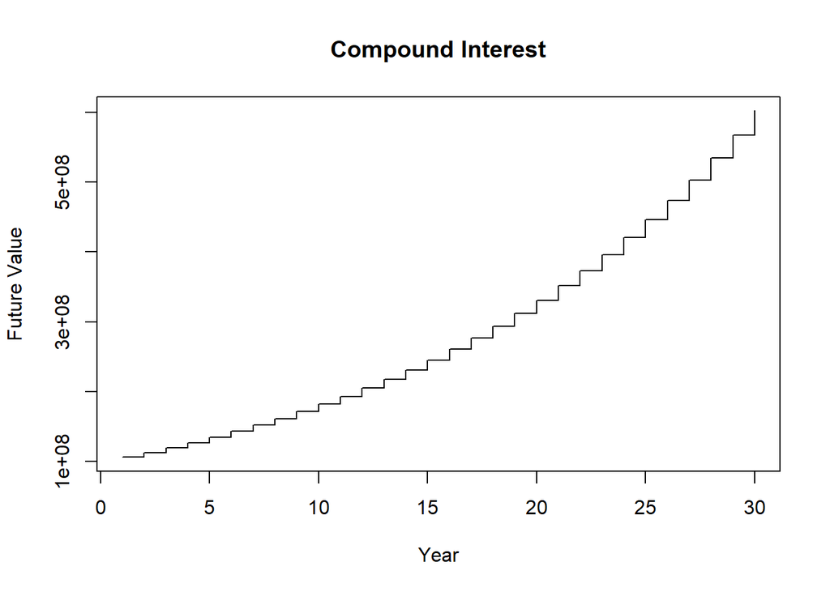

## 77. Định nghĩa computeMatrix(m) với m là ma trận vuông chứa chuỗi. Nếu đường chéo chính có chuỗi bắt đầu bằng ký tự g hoặc G thì thay các chuỗi đó bằng “here”; nếu không có chuỗi nào như vậy, thay toàn bộ ma trận bằng ma trận đơn vị cùng bậc. Kiểm tra bằng ba ma trận mẫu trong file lab.

```r
computeMatrix <- function(m){
  d <- diag(m)
  check <- grepl("^[gG]", d)
  if(any(check)){
    diag(m)[check] <- "here"
  } else {
    m <- diag(nrow(m))
  }
  return(m)
}

### Ma trận mẫu 1

m1 <- matrix(
  c("go", "a",
    "b", "Good"),

  nrow = 2,
  byrow = TRUE
)
computeMatrix(m1)
```

```
##      [,1]   [,2]
## [1,] "here" "a"
## [2,] "b"    "here"
```

```r
### Ma trận mẫu 2

m2 <- matrix(
  c("apple", "b",
    "c", "dog"),

  nrow = 2,
  byrow = TRUE
)
computeMatrix(m2)
```

```
##      [,1] [,2]
## [1,]    1    0
## [2,]    0    1
```

```r
### Ma trận mẫu 3

m3 <- matrix(
  c("Green", "x", "y",
    "a", "hello", "b",
    "c", "d", "game"),

  nrow = 3,
  byrow = TRUE
)

computeMatrix(m3)
```

```
##      [,1]   [,2]    [,3]
## [1,] "here" "x"     "y"
## [2,] "a"    "hello" "b"
## [3,] "c"    "d"     "here"
```